# HW 2: CONJ 620 W22

Solutions

Due Wed 1/19/22

```r
library(tidyverse)
library(janitor)

# new
library(skimr)
```

## Directions

- For self-grading your assignment, please start with the Part 1 .Rmd file that you already uploaded to Sakai, and make your corrections to that.
  - Add to the beginning of each question your reflection / grading of your response in your original submission in purple so that we can easily distinguish your Part 2 grading from your original Part 1 answer.
  - Check out the code in the Rmd file for how I made this text purple using html code (you can’t see it in the html output).
    - Don’t forget to end the purple text with the code right after this sentence.
- Please upload Part 2 of your homework to Sakai. Upload both your .Rmd code file and the knitted .html file.
  - If you do not upload the html file of your knitted Rmd file, 20 (out of 100) points will be deducted from your homework grade. *If there is an error with code in a code chunk that is preventing the file from knitting, then comment out that code and make a note that it’s not running.*
- The questions are numbered 1-14. Please do not use `(@)` in your edits to this file so that the exercise numbering does not change!
- For each question, make sure to include all code and resulting output in the html file to support your answers. Answers to questions do not need be lengthy, but thoughtful and descriptive.

> Tip: It is a good idea to try kitting your document from time to time as you go along! Note that knitting automatically saves your Rmd file and knitting frequently helps you catch your errors more quickly.

# Hypothyroidism data Background

- The data are from a random sample of patients from the study described below.
- *Effects of Altering Levothyroxine Dose on Energy Expenditure and Body Composition in Subjects Treated With LT4* by Samuels et al. (J Clin Endocrinol Metab, November 2018, 103(11):4163–4175).

From the paper:

> **Background:** It is unclear whether variations in thyroid status within or near the reference range affect energy expenditure, body mass, or body composition.

> **Methods:** 138 subjects treated with levothyroxine (LT4) for hypothyroidism with normal TSH levels underwent measurement of total, resting, and physical activity energy expenditure; thermic effect of food; substrate oxidation; dietary intake; and body composition. They were assigned to receive an unchanged, higher, or lower LT4 dose in randomized, double-blind fashion, targeting one of three TSH ranges (0.34 to 2.50, 2.51 to 5.60, or 5.61 to 12.0 mU/L). The doses were adjusted every 6 weeks to achieve target TSH levels. Baseline measures were reassessed at 6 months.

# Load the data

```r
ddd <- read_csv("data/tsh_hw2.csv")
```

Explore the dataset.

1. **How many observations and variables are included in this dataset? Are there repeated measures amongst the patients? How did you determine this?**

```r
dim(ddd)
```

```
## [1] 240  17
```

```r
length(unique(ddd$id))
```

```
## [1] 120
```

```r
ddd %>% tabyl(time)
```

```
##      time   n percent
##  baseline 120     0.5
##  endpoint 120     0.5
```

- There are 17 variables in the dataset, with 240 observations.
- Patients in the dataset have repeated measures. One hint that this is the case is that there is a time variable with baseline and endpoint values. Furthermore, there are 120 unique id’s and 240 rows, which is 2 rows per id.

# Data wrangling

2. **Make a table of the values in the `baseline_group` group variable. Add a new variable to the dataset called `TSH_group_baseline`, which renames the levels of `baseline_group` so that 1 is now `LowNormal` and 2 is `HighNormal`.**

```r
ddd %>% tabyl(baseline_group)
```

```
##  baseline_group   n   percent
##               1 160 0.6666667
##               2  80 0.3333333
```

```r
ddd <- ddd %>%
  mutate(
    TSH_group_baseline = case_when(
      baseline_group == 1 ~ "LowNormal",
      baseline_group == 2 ~ "HighNormal"
      )
    )
```

Check (question didn’t explicitly ask for this, but it’s a good idea to check your work):

```r
ddd %>% tabyl(baseline_group, TSH_group_baseline)
```

```
##  baseline_group HighNormal LowNormal
##               1          0       160
##               2         80         0
```

3. **Create a new dataset that only includes the variables `id`, `time`, `TSH_group_baseline`, and `tsh`. Check that your code did what you expected it to.**

```r
ddd_tsh <- ddd %>%
  select(id, time, TSH_group_baseline, tsh)

# check
dim(ddd)
```

```
## [1] 240  18
```

```r
dim(ddd_tsh)
```

```
## [1] 240   4
```

```r
names(ddd_tsh)
```

```
## [1] "id"                 "time"               "TSH_group_baseline"
## [4] "tsh"
```

The new dataset contains only the specified columns, and still has the same number of rows.

## Make data wide

- In this section we are going to use two different ways to make the long (by time point) data wide, using the smaller dataset created in the previous problem.
- The goal is to create a dataset with separate columns for the baseline and endpoint TSH values.

### Method 1

4. **Create two separate datasets, where one is restricted to the baseline values and the other is restricted to the endpoint values. Rename the `tsh` variable in the two datasets as `tsh_baseline` and `tsh_endpoint`, respectively. Check that your code did what you expected it to.**

```r
# check to see names of time variable levels
ddd_tsh %>% tabyl(time)
```

```
##      time   n percent
##  baseline 120     0.5
##  endpoint 120     0.5
```

- baseline data:

```r
ddd_tsh_baseline <- ddd_tsh %>%
  filter(time == "baseline") %>%
  rename(tsh_baseline = tsh)

# check
head(ddd_tsh_baseline)
```

```
## # A tibble: 6 x 4
##      id time     TSH_group_baseline tsh_baseline
##   <dbl> <chr>    <chr>                     <dbl>
## 1     1 baseline LowNormal                  1.05
## 2     2 baseline LowNormal                  1.78
## 3     3 baseline LowNormal                  2.43
## 4     4 baseline LowNormal                  2.3
## 5     6 baseline LowNormal                  0.63
## 6     7 baseline LowNormal                  0.27
```

```r
ddd_tsh_baseline %>% tabyl(time) # all time values are baseline and have 120 values
```

```
##      time   n percent
##  baseline 120       1
```

- endpoint data:

```r
ddd_tsh_endpoint <- ddd_tsh %>%
  filter(time == "endpoint") %>%
  rename(tsh_endpoint = tsh)

# check
head(ddd_tsh_endpoint)
```

```
## # A tibble: 6 x 4
##      id time     TSH_group_baseline tsh_endpoint
##   <dbl> <chr>    <chr>                     <dbl>
## 1     1 endpoint LowNormal                  1.87
## 2     2 endpoint LowNormal                  1.49
## 3     3 endpoint LowNormal                  3.62
## 4     4 endpoint LowNormal                  2.9
## 5     6 endpoint LowNormal                  3.02
## 6     7 endpoint LowNormal                  2.72
```

```r
ddd_tsh_endpoint %>% tabyl(time) # all time values are endpoint and have 120 values
```

```
##      time   n percent
##  endpoint 120       1
```

5. **Remove the `time` column from the two datasets. Check that your code did what you expected it to.**

```r
ddd_tsh_baseline <- ddd_tsh_baseline %>%
  select(-time)
# check: time not included
names(ddd_tsh_baseline)
```

```
## [1] "id"                 "TSH_group_baseline" "tsh_baseline"
```

```r
ddd_tsh_endpoint <- ddd_tsh_endpoint %>%
  select(-time)
# check: time not included
names(ddd_tsh_endpoint)
```

```
## [1] "id"                 "TSH_group_baseline" "tsh_endpoint"
```

6. **Merge the baseline data and endpoint data together as one dataset with separate columns for the baseline and endpoint TSH data. Check that your code did what you expected it to.**

```r
names(ddd_tsh_baseline)
```

```
## [1] "id"                 "TSH_group_baseline" "tsh_baseline"
```

```r
names(ddd_tsh_endpoint)
```

```
## [1] "id"                 "TSH_group_baseline" "tsh_endpoint"
```

```r
# I use `left_join` below.
# This can be done with the other join functions as well.

ddd_tsh_wide1 <- left_join(
  ddd_tsh_baseline,
  ddd_tsh_endpoint,
  by = c("id", "TSH_group_baseline")
  )

# check
dim(ddd_tsh_wide1)
```

```
## [1] 120   4
```

```r
length(unique(ddd_tsh_wide1$id))
```

```
## [1] 120
```

```r
names(ddd_tsh_wide1)
```

```
## [1] "id"                 "TSH_group_baseline" "tsh_baseline"
## [4] "tsh_endpoint"
```

```r
head(ddd_tsh_wide1)
```

```
## # A tibble: 6 x 4
##      id TSH_group_baseline tsh_baseline tsh_endpoint
##   <dbl> <chr>                     <dbl>        <dbl>
## 1     1 LowNormal                  1.05         1.87
## 2     2 LowNormal                  1.78         1.49
## 3     3 LowNormal                  2.43         3.62
## 4     4 LowNormal                  2.3          2.9
## 5     6 LowNormal                  0.63         3.02
## 6     7 LowNormal                  0.27         2.72
```

The wide dataset has one row for each id (120 rows), and separate columns for the baseline and endpoint TSH data.

### Method 2

7. **Use one of the `pivot` commands to make the dataset wide for the TSH values at the two different time points. Check that your code did what you expected it to.**

```r
names(ddd_tsh)
```

```
## [1] "id"                 "time"               "TSH_group_baseline"
## [4] "tsh"
```

```r
ddd_tsh_wide2 <- ddd_tsh %>%
  pivot_wider(names_from = "time",
              values_from = "tsh",
              names_prefix = "tsh_")

# check
dim(ddd_tsh_wide2)
```

```
## [1] 120   4
```

```r
length(unique(ddd_tsh_wide2$id))
```

```
## [1] 120
```

```r
names(ddd_tsh_wide2)
```

```
## [1] "id"                 "TSH_group_baseline" "tsh_baseline"
## [4] "tsh_endpoint"
```

```r
head(ddd_tsh_wide2)
```

```
## # A tibble: 6 x 4
##      id TSH_group_baseline tsh_baseline tsh_endpoint
##   <dbl> <chr>                     <dbl>        <dbl>
## 1     1 LowNormal                  1.05         1.87
## 2     2 LowNormal                  1.78         1.49
## 3     3 LowNormal                  2.43         3.62
## 4     4 LowNormal                  2.3          2.9
## 5     6 LowNormal                  0.63         3.02
## 6     7 LowNormal                  0.27         2.72
```

The wide dataset has one row for each id (120 rows), and separate columns for the baseline and endpoint TSH data.

# TSH values: baseline vs. endpoint

8. **Make a scatterplot with endpoint TSH values on the vertical axis, baseline TSH values on the horizontal axis, with dots color coded by the `TSH_group_baseline` variable.**

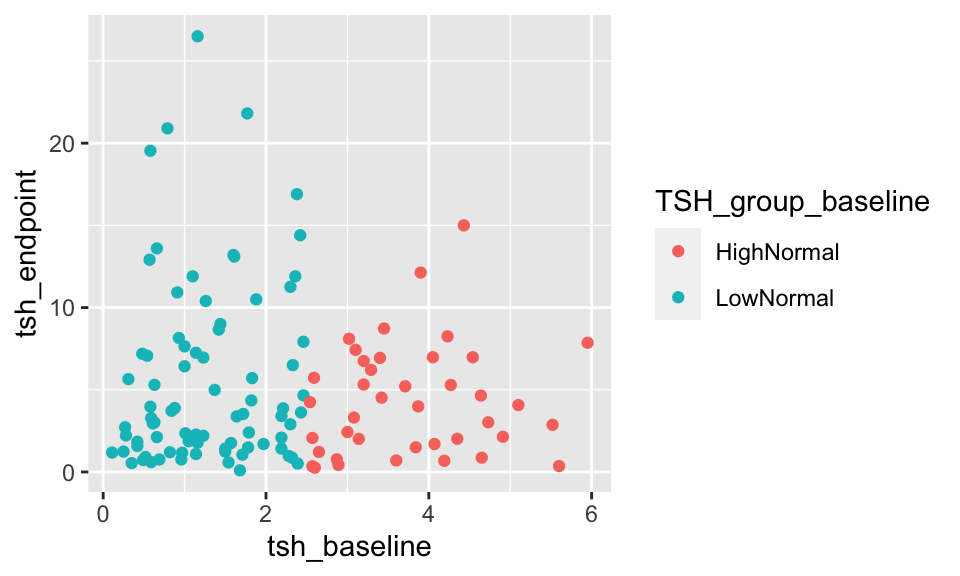

```r
ggplot(ddd_tsh_wide1,
       aes(x = tsh_baseline,
           y = tsh_endpoint,
           color = TSH_group_baseline)) +
  geom_point()
```

9. **Describe the association between the baseline and endpoint TSH values.**

There does not seem to be an association between the baseline and endpoint TSH values. There is no clear pattern amongst the points.

10. **Add a variable called `TSH_group_endpoint` to the dataset categorizing the endpoint TSH values as being in the TSH groups listed below:**
- `LowNormal` TSH (0.34 to 2.50 mU/L)
- `HighNormal` TSH (2.51 to 5.60 mU/L)
- `Elevated` TSH (greater than 5.60 mU/L)

```r
ddd_tsh_wide1 <- ddd_tsh_wide1 %>%
  mutate(
    TSH_group_endpoint = case_when(
      tsh_endpoint <= 2.50 ~ "LowNormal",
      tsh_endpoint > 2.50 & tsh_endpoint <= 5.60 ~ "HighNormal",
      tsh_endpoint > 5.60 ~ "Elevated"
    )
  )

head(ddd_tsh_wide1)
```

```
## # A tibble: 6 x 5
##      id TSH_group_baseline tsh_baseline tsh_endpoint TSH_group_endpoint
##   <dbl> <chr>                     <dbl>        <dbl> <chr>
## 1     1 LowNormal                  1.05         1.87 LowNormal
## 2     2 LowNormal                  1.78         1.49 LowNormal
## 3     3 LowNormal                  2.43         3.62 HighNormal
## 4     4 LowNormal                  2.3          2.9  HighNormal
## 5     6 LowNormal                  0.63         3.02 HighNormal
## 6     7 LowNormal                  0.27         2.72 HighNormal
```

11. **Calculate minimum and maximum summary statistics for the endpoint TSH values stratified by `TSH_group_endpoint`. Do the min and max values agree with the group values listed above?**

Yes, the values agree.

```r
ddd_tsh_wide1 %>%
  group_by(TSH_group_endpoint) %>%
  summarise(
    across(tsh_endpoint,
           c(min = min, max = max), na.rm = TRUE)
    )
```

```
## # A tibble: 3 x 3
##   TSH_group_endpoint tsh_endpoint_min tsh_endpoint_max
##   <chr>                         <dbl>            <dbl>
## 1 Elevated                       5.65            26.5
## 2 HighNormal                     2.72             5.32
## 3 LowNormal                      0.1              2.43
```

```r
# Check: note that I hadn't shown you skim() yet when you did the assignment. skim() together with group_by() is a good check for this

ddd_tsh_wide1 %>%
  group_by(TSH_group_endpoint) %>%
  skim(tsh_endpoint)
```

Data summary

| Name | Piped data |
| --- | --- |
| Number of rows | 120 |
| Number of columns | 5 |
| _______________________ |  |
| Column type frequency: |  |
| numeric | 1 |
| ________________________ |  |
| Group variables | TSH_group_endpoint |

**Variable type: numeric**

| skim_variable | TSH_group_endpoint | n_missing | complete_rate | mean | sd | p0 | p25 | p50 | p75 | p100 | hist |
| --- | --- | --- | --- | --- | --- | --- | --- | --- | --- | --- | --- |
| tsh_endpoint | Elevated | 0 | 1 | 10.50 | 4.84 | 5.65 | 7.00 | 8.46 | 12.72 | 26.50 | ▇▃▁▁▁ |
| tsh_endpoint | HighNormal | 0 | 1 | 3.93 | 0.82 | 2.72 | 3.30 | 3.88 | 4.55 | 5.32 | ▇▇▇▅▆ |
| tsh_endpoint | LowNormal | 0 | 1 | 1.31 | 0.66 | 0.10 | 0.76 | 1.23 | 1.86 | 2.43 | ▅▇▇▅▇ |

```r
# the max and min LowNormal, HighNormal, and Elevated values are all within the ranges as specified above
```

12. **Make a contingency table of the TSH baseline vs. endpoint groups, that includes row and column totals.**

```r
ddd_tsh_wide1 %>%
  tabyl(TSH_group_baseline,
        TSH_group_endpoint) %>%
  adorn_totals(c("row", "col"))
```

```
##  TSH_group_baseline Elevated HighNormal LowNormal Total
##          HighNormal       13         11        16    40
##           LowNormal       29         17        34    80
##               Total       42         28        50   120
```

13. **What percent of people that started in the high normal TSH group ended in the low normal TSH group?**

```r
ddd_tsh_wide1 %>%
  tabyl(TSH_group_baseline,
        TSH_group_endpoint) %>%
  adorn_percentages(denominator = "row") %>%
  adorn_totals(c("row", "col")) %>%
  adorn_pct_formatting(digits = 1)
```

```
##  TSH_group_baseline Elevated HighNormal LowNormal  Total
##          HighNormal    32.5%      27.5%     40.0% 100.0%
##           LowNormal    36.2%      21.2%     42.5% 100.0%
##               Total    68.8%      48.8%     82.5% 200.0%
```

40% of people that started in the high normal TSH group ended in the low normal TSH group.

14. **What percent of people that started in the low normal TSH group ended in the elevated TSH group?**

36.2% of people that started in the low normal TSH group ended in the elevated TSH group.